# Final Examination: Report

Udeshi Salgado - AS2018517

10/7/2021

#### STA 472 2.0 - Special Topics in Statistics

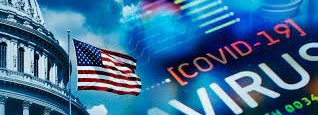

```r
# Packages
# remotes::install_github("kjhealy/covdata@main")
library(covdata)
library(tidyverse)
library(scales)
library(plotly)
library(ggplot2)
library(dplyr)
```

## Visualization 01:

### Topic: Cumulative Weekly Death Counts of United States, by Top 5 Causes in 2020-2021

```r
# Considering the period between 2020 - 2021
nchs_wdc1 <- nchs_wdc %>% filter(year>=2020)
# Choosing year, week, death counts and causes from dataframe
nchs_wdc2 <- nchs_wdc1 %>% select(year, week, n, cause)
# Replacing COVID-19 Underlying as COVID-19
nchs_wdc2$cause <- replace(nchs_wdc2$cause, nchs_wdc2$cause=="COVID-19 Underlying","COVID-19")
# Choosing top 5 causes in 2020-2021
nchs_wdc2 <- filter(nchs_wdc2, cause %in% c("Chronic Lower Respiratory Diseases","COVID-19", "Diabetes","Cancer","Cerebrovascular Diseases"))
# Replacing NAs with zero
nchs_wdc2$n <- replace(nchs_wdc2$n, is.na(nchs_wdc2$n)==TRUE, 0)
# Ordering data frame based on year and  week
nchs_wdc2 <- nchs_wdc2[order(nchs_wdc2$year,nchs_wdc2$week),]
# Aggregating death counts with respect to year, week and cause type
nchs_wdc3 <- aggregate(nchs_wdc2$n, by=list(nchs_wdc2$year, nchs_wdc2$week, nchs_wdc2$cause), sum)
# Changing the column names
colnames(nchs_wdc3) <- c("Year", "Week", "Disease", "Death_Count")
# Order Dataframe based on Year and Week
nchs_wdc3 <- nchs_wdc3[order(nchs_wdc3$Year,nchs_wdc3$Week),]
# Turning dataframe into pivot wider format
nchs_wdc4 <- nchs_wdc3 %>%
  pivot_wider(names_from = Disease, values_from = Death_Count)
# Adding Week Count Column
nchs_wdc4$week_count <- 1:86
# Taking cumulative death counts of each causes separately
# Cancer
nchs_wdc4$Cancer <- cumsum(nchs_wdc4$Cancer)
# Chronic
nchs_wdc4$`Chronic Lower Respiratory Diseases` <- cumsum(nchs_wdc4$`Chronic Lower Respiratory Diseases`)
# COVID-19
nchs_wdc4$`COVID-19` <- cumsum(nchs_wdc4$`COVID-19`)
# Diabetes
nchs_wdc4$Diabetes <- cumsum(nchs_wdc4$Diabetes)
# Cerebrovascular Diseases
nchs_wdc4$`Cerebrovascular Diseases` <- cumsum(nchs_wdc4$`Cerebrovascular Diseases`)
# Turning dataframe into pivot longer format
nchs_wdc5 <- nchs_wdc4 %>%
  pivot_longer(3:7, names_to = "Cause", values_to = "Cumulative_Death_Count")
# Visualizing plot
viz_01 <- plot_ly(nchs_wdc5,
               x = ~sort(week_count),
               y = ~Cumulative_Death_Count,
               type = 'scatter',
               mode = 'lines',
               color = ~Cause,
               colors= "Dark2")  %>%
               layout(title = "Cumulative Weekly Death Counts of United States, by Top 5 Causes in 2020-2021",
                      legend = list(orientation = 'h', x = 0.1, y = -0.3, title=list(text='<b> Cause Type </b>')),
                      yaxis = list(title = "Cumulative Death Count"),
                      xaxis = list(title = "Week"),
                      margin = list(b = 100))

viz_01
```

[interactive chart not shown]

Figure 01

#### Interpretation

Chronic Lower Respiratory Diseases, COVID-19, Diabetes, Cancer, and Cerebrovascular Diseases are the five leading causes of death in the United States. It is noticeable by Figure 01 that COVID-19 is the second leading cause of death during the period 2020-2021, with 1.1 Million total number cumulative deaths at the end of August 2021. COVID-19 has already passed the weekly cumulative death counts caused by Chronic Lower Respiratory Diseases, Cerebrovascular Diseases, and Diabetes for 2020-2021.

## Visualization 02:

### Topic: Daily Total Number of Tests Ecountered Vs Daily Confirmed Cases by Test Type in United States

```r
# Removing data_quality_grade, since it's a NA column
# Removing flips column as it share the same data as state column
# removing measure column as it share the same data as measure label column
# Choosing date, measure and count columns
covus1 <- covus %>% select(date, measure_label, count)
# Replacing NA death counts with zero
covus1$count <- replace(covus1$count, is.na(covus1$count)== TRUE, 0)
# Taking sum of death counts with respect to date and measure label
covus2 <- aggregate(covus1$count, by = list(covus1$date, covus1$measure_label), sum)
# Changing column names
colnames(covus2) <- c("date", "Measure", "Count")
# Choosing antibody, antigen, and PCR test types and date after January 21st, 2020
total_test <- covus2 %>% filter(Measure==c("Total Test Encounters (PCR)","Total Antigen Tests" ,"Total Antibody Tests") & covus2$date>="2020-01-21" )
# Change dataframe into pivot-wider format
total_test <- total_test %>%
  pivot_wider(names_from = Measure, values_from = Count)
colnames(total_test) <- c("date","antibody","antigen","pcr")
# Choosing daily confirmed cases with date and considering time before March 07th, 2021
daily_cases <- nytcovus %>% select(date, cases) %>%
  filter(nytcovus$date<="2021-03-07")
# Joining two dataframes, daily_cases and total_test
new_df <- right_join(total_test,daily_cases, by= c("date"= "date"))
#Changing dataframe into pivot longer format
new_df <- new_df %>% pivot_longer(2:4, names_to = "test_type", values_to = "test_count")

# Visualizing plot
viz_02 <- plot_ly(na.omit(new_df),
                  x = ~cases,
                  y = ~test_count,
                  type = 'scatter',
                  mode = 'lines',
                  color = ~test_type,
                  colors = "Dark2") %>%
  layout(title = "Daily Total Number of Tests Ecountered Vs Daily Confirmed Cases by Test Type in United States",
         legend = list(orientation = 'v', x = 100, y = 0.9, title=list(text='<b> Test Type </b>')),
         yaxis = list(title = "Daily Confirmed Cases"),
         xaxis = list(title = "Daily Total Number of Tests Ecountered"),
         margin = list(b = 100))

viz_02
```

[interactive chart not shown]

Figure 02

#### Interpretation

It can be shown in figure 02 that all 3 test types, antibody, antigen, and PCR, have a positive relationship with the number of confirmed cases implying that the higher the number of COVID-19 tests encountered, the higher the number of confirmed cases.

Moreover, it can be considered as the number of PCR tests encountered and confirmed cases have an almost linear positive relationship, as the number of cases increases along with the number of tests encountered with an almost exact rate.

In conclusion, it can be said that if the United States increased the number of COVID-19 tests, it would result in a higher number of confirmed cases concerning Figure 02.

## Visualization 03:

### Topic: United States: Distribution of Daily COVID-19 Confirmed Cases By Regions

```r
# Choosing statefips and region_name from uspop dataframe
us_region <- uspop %>% select(statefips, region_name)
# Taking unique sets of statefips and region_name
us_region <- distinct(us_region)
# Region for statefip 11 is missing and replacing it with respective region, Northwest
us_region$region_name <- replace(us_region$region_name, is.na(us_region$region_name)== TRUE, "Northeast")
# Choosing date, fips and cases columns from nytcovstate
covstate <- nytcovstate %>% select(date, fips, cases)
# Fips 78, 66, 72, and 69 do not belong to any of these primary regions of the United States as per US geographical data
# Remove those rows from dataframe
covstate <- covstate %>% filter(fips %in% us_region$statefips)
# Changing column names of us_region
colnames(us_region) <- c("fips", "region")
# Combining two dataframes, us_region and covstate
covstate1 <- covstate %>% full_join(us_region)
# Taking sum of cumulative cases with respect to date and region
covstate1 <- aggregate(covstate1$cases, by= list(covstate1$date, covstate1$region), sum)
# Changing the column names of the dataframe
colnames(covstate1) <- c("date", "region", "cases")
# Turning dataframe into pivot-wider format
covstate_wide <- covstate1 %>%
  pivot_wider(names_from = region, values_from = cases)
# Replacing NA values with zero
covstate_wide <- replace(covstate_wide, is.na(covstate_wide)==TRUE, 0)
# Order the dataframe data with respect to date
covstate_wide <- covstate_wide[order(covstate_wide$date),]
# Turning dataframe into pivot-longer format
covstate_long <- covstate_wide %>%
  pivot_longer(2:5, names_to = "region", values_to = "cumcases")
# Converting cumulative confirmed cases into daily confirmed cases
covstatenew <- covstate_long %>% group_by(region) %>%
  mutate(cases =  c(cumcases[1], abs(diff(cumcases))))
# Calculating regional death averages
cases_means <- covstatenew %>%
  group_by(region) %>%
  summarize(mean_val = mean(cases))

# Visualizing plot
viz_03 <- ggplot(covstatenew, aes(x=date, y=cases, fill=region)) +
  geom_bar(stat = 'identity')  +
  scale_fill_brewer(type = 'qual', palette = 'Dark2') +
  theme(panel.grid.major = element_blank(), panel.grid.minor = element_blank()) +
  scale_y_continuous(labels = label_number(suffix = "K", scale = 1e-3)) +
  geom_hline(data= cases_means, aes(yintercept=mean_val), colour="black") +
  facet_grid(region~.) +
  labs(title="United States: Distribution of Daily COVID-19 Confirmed Cases By Regions", x="Date", y="No of Cases")
ggplotly(viz_03)
```

[interactive chart not shown]

Figure 03

#### Interpretation

Figure 03 shows how the confirmed cases of 4 primary regions vary with time. It can be identified that all four regions have faced two COVID-19 waves, and currently, all of them are facing the third wave. All four regions have faced the second wave at the beginning of 2021, and the South region shows comparatively large confirmed cases while the Northeast shows the lowest.

Northeast shows the lowest average confirmed cases, compared to three other regions. Even though it shows comparatively high confirmed cases in the beginning. Moreover, South shows the highest average confirmed cases, compared to three other regions. Both Midwest and West regions show almost the same average confirmed cases and almost the same number of cases during COVID-19 waves.

In conclusion, it is reasonable to argue that regional areas affect the number of daily confirmed cases in the United States. Climate, geographical situation, culture, and economic situation differ from region to region, and it might be the reasons for the different patterns in COVID-19 confirmed cases in the United States.

## Visualization 04:

### Topic: Deaths By Age Group, in United States during 2020 - August 2021

```r
# Filtering by total rows
nchs_sas <- nchs_sas %>% filter(group=="By Total")
# Filtering rows belongs to US as a whole
nchs_sas <- nchs_sas %>% filter(state=="United States")
# Filtering All Sexes rows
nchs_sas <- nchs_sas %>% filter(sex=="All Sexes")
# Filtering total,COVID-19 and pneumonia with COVID19 death rows from the dataframe
nchs_sas <- nchs_sas %>% select(age_group,pneumonia_and_covid_19_deaths,covid_19_deaths,total_deaths)
# Ages are categorized in 2 ways other than All Ages
# Removing All Ages and  one age categorized type rows
nchs_sas <- nchs_sas[-c(1,2,4,5,6,8,10,12,14),]
# Changing column names
colnames(nchs_sas) <- c("age_group", "pneumonia+covid19", "covid_19", "total")
# Turning dataframe into pivot-longer format
nchs_sas_long <- nchs_sas %>%
  pivot_longer(2:4, names_to = "death_type", values_to = "death_count")

# Visualizing plot
viz_04 <- ggplot(nchs_sas_long, aes(x = death_type, y = death_count, fill = death_type)) +
  geom_bar(stat = 'identity') + facet_wrap(~ age_group) +
  coord_flip() +
  theme(panel.grid.major = element_blank(), panel.grid.minor = element_blank()) +
  scale_fill_brewer(type = 'qual', palette = 'Dark2') +
  labs(title="Deaths By Age Group, in United States during 2020 - August 2021",
       x="Death Type",
       y="Death Count")
ggplotly(viz_04)
```

[interactive chart not shown]

Figure 04

#### Interpretation

Figure 04 reflects that the risk of dying increases with age, the same for COVID-19, pneumonia with COVID-19, and total deaths in the United States from 2020 to August 2021.

It can be identified that no COVID-19 death has occurred, age between 0-17, implying that both children and teenagers have a high survival rate during the COVID-19 pandemic compared to other age groups.

Youth represents age between 18-29 years, and only around 3000 COVID-19 deaths occurred, and none of them represent a COVID-19 death with pneumonia. This implies that youth has a high immunity compared with ages above 29 to fight with pneumonia COVID-19 situation.

Youth shows high COVID-19 death counts compared to children and teenagers between 0-17 years. Therefore, it can be concluded that the reasons for this number of youth COVID-19 deaths might be that youth have more chance of getting infected as they might work as front-line workers compared to 0-17 ages, and ignoring symptoms might lead to the COVID-19 deaths.

Middle ages have a somewhat risk of being a victim of COVID-19 and pneumonia COVID-19, and Figure 04 shows moderate death counts for middle ages compared to other age groups.

Figure 04 implies that ages above 50 have a high risk of being victims of COVID-19 and pneumonia COVID-19. Moreover, Figure 04 clearly shows that the ages above 75 have the highest COVID-19, pneumonia COVID-19 and total death counts.

In conclusion, it can be concluded that older adults have a high risk of being a victim of COVID-19 and pneumonia COVID-19, and less immunity of older adults compared to other ages might be the reason for this.

## References

Abadi, M., 2018. Insider. [Online] Available at: https://www.businessinsider.com/regions-of-united-states-2018-5#the-us-census-bureau-divides-the-united-states-into-four-regions-theres-the-northeast--1 [Accessed 5 October 2021].

Study.com, 2021. What are the Regions of the United States?. [Online] Available at: https://study.com/academy/lesson/what-are-the-regions-of-the-united-states.html [Accessed 5 October 2021].

United States Department of Agriculture, 2021. State FIPS Codes. [Online] Available at: https://www.nrcs.usda.gov/wps/portal/nrcs/detail/?cid=nrcs143_013696 [Accessed 5 October 2021].